# Creative Gaming

## Part 4: Better Data, Better Predictions

Mi Hiruki called for a meeting to plan the next steps. She explained: “Before we roll out the campaign globally, we want to see whether we can use the experimental data to retrain the model. The idea is to model trial in response to the in-app ad, not just organic conversion, as we did initially. We know that the in-app ad, on average, increases Zalon conversions. However, if the in-app ad works for people who would not have purchased the Zalon campaign organically, updating the model based on the in-app ad data should improve predictive performance. Let’s retrain the model based on the randomly chosen Space Pirates users we messaged in the experiment and see how well the updated model compares to the original model in a test sample.”

1. Retrain the logistic regression model from Part 2 (which was trained on “cg_organic_train”) on the sample of customers who were exposed to the ad campaign (“cg_ad_random”). Instead of creating separate training/test datasets, please use the full 30,000 sample “cg_ad_random” you created in Part 3, Q2 to train the model.

```r
cg_ad_random2 <- cg_ad_treatment[sample_random_30000,]
lr_ad_random <- glm(converted ~ ., family=binomial(logit), data=cg_ad_random2)
```

2. Compare the performance of the original “organic” model from Part 2 and the “ad” model on the “cg_ad_scoring” sample you created in Part 3, Q3. Use gains curves and AUC to make the comparison. What do you find?

| model | auc |
| --- | --- |
| cg_ad_scoring$score_lr | 0.644 |
| cg_ad_scoring$score_lr_ad_random | 0.703 |

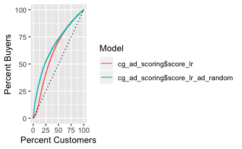

```r
cg_ad_scoring <- cg_ad_scoring %>%
   mutate(
      score_lr_ad_random = predict(lr_ad_random, newdata=cg_ad_scoring, type="response"),
   )

gainsplot(cg_ad_scoring$score_lr, cg_ad_scoring$score_lr_ad_random, label.var = cg_ad_scoring$converted)
```

3. Calculate the profit improvement of using a model trained on ad treatment instead of organic data to target the best 30,000 customers in the “cg_ad_scoring” sample.

```r
quartileNew <- cg_ad_scoring %>%
   mutate(pred_buyer_quartile = ntile(-score_lr_ad_random, 4)) %>%
   group_by(pred_buyer_quartile) %>%
   summarise(num_cust=n(), num_buyers=sum(converted), resp_rate=sum(converted)/n(), pred_resp_rate=mean(score_lr))

# TODO: This has to be wrong... Resp Rates are way higher than Predicted Response Rate
quartileNew
```

| pred_buyer_quartile | num_cust | num_buyers | resp_rate | pred_resp_rate |
| --- | --- | --- | --- | --- |
| 1 | 30000 | 8217 | 0.2739 | 0.1395 |
| 2 | 30000 | 3281 | 0.1094 | 0.0986 |
| 3 | 30000 | 2360 | 0.0787 | 0.0560 |
| 4 | 30000 | 1877 | 0.0626 | 0.0274 |

```r
profitByQuartileNew <- quartileNew[1,] %>%
   mutate(revenue=num_buyers * revenue_per, cost=num_buyers * cost_per, profit=revenue-cost) %>%
   select(pred_buyer_quartile, num_cust, num_buyers, resp_rate, revenue, cost, profit)

paste("Orig Profit: ", dollar(profitByQuartileOrig$profit),
      "New Profit: ", dollar(profitByQuartileNew$profit),
      "Improvement: ", dollar(profitByQuartileNew$profit -profitByQuartileOrig$profit ))
```

```
[1] "Orig Profit:  $87,037.48 New Profit:  $110,847 Improvement:  $23,809.85"
```

4. Compare the variable importance plot of the “organic” model and the “ad” model to explain why the performance of the models differ.

| variable | factor | var_imp | var_imp_lower | var_imp_upper | p_value |
| --- | --- | --- | --- | --- | --- |
| NumSpaceHeroBadges | No | 1.28012 | 1.2016 | 1.35862 | 0.000 |
| TimesLostSpaceship | No | -0.91013 | -1.1440 | -0.67625 | 0.000 |
| NumFriendRequestIgnored | No | -0.80461 | -0.9764 | -0.63284 | 0.000 |
| GameLevel | No | 0.57684 | 0.4236 | 0.73004 | 0.000 |
| AcquiredSpaceship1 | Yes | 0.53822 | 0.3973 | 0.67912 | 0.000 |
| AcquiredIonWeapon1 | Yes | 0.47795 | 0.0798 | 0.87608 | 0.019 |
| NumGameDays | No | 0.46940 | 0.3175 | 0.62126 | 0.000 |
| NumAdsClicked | No | 0.39750 | 0.2890 | 0.50597 | 0.000 |
| TimesNavigator | No | -0.39284 | -0.6062 | -0.17946 | 0.000 |
| NumInGameMessagesSent | No | 0.31259 | 0.1579 | 0.46725 | 0.000 |

[output cut: 9 more lines]

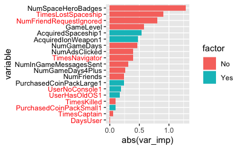

```r
varimp.logistic(lrm) %>% plotimp.logistic()
```

| variable | factor | var_imp | var_imp_lower | var_imp_upper | p_value |
| --- | --- | --- | --- | --- | --- |
| NumAdsClicked | No | 1.21855 | 1.15829 | 1.2788 | 0.000 |
| NumFriends | No | 0.35897 | 0.29490 | 0.4230 | 0.000 |
| GameLevel | No | 0.29306 | 0.21155 | 0.3746 | 0.000 |
| NumGameDays | No | 0.21736 | 0.13472 | 0.3000 | 0.000 |
| UserHasOldOS1 | Yes | -0.20570 | -0.33913 | -0.0723 | 0.003 |
| TimesLostSpaceship | No | -0.16411 | -0.26661 | -0.0616 | 0.002 |
| PurchasedCoinPackLarge1 | Yes | 0.16203 | 0.08224 | 0.2418 | 0.000 |
| AcquiredIonWeapon1 | Yes | -0.12866 | -0.40022 | 0.1429 | 0.353 |
| NumSpaceHeroBadges | No | 0.09602 | 0.02630 | 0.1657 | 0.007 |
| TimesCaptain | No | 0.08958 | 0.03073 | 0.1484 | 0.003 |

[output cut: 9 more lines]

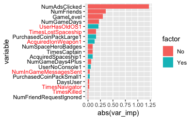

```r
varimp.logistic(lr_ad_random) %>% plotimp.logistic()
```

```r
"
It appears the models differ because the original buyers of the expansion pack included
power users. The introduction of the ad changes the model to include new users regardless
of in-app telemtry data.
"
```

```
[1] "\nIt appears the models differ because the original buyers of the expansion pack included\npower users. The introduction of the ad changes the model to include new users regardless\nof in-app telemtry data.\n"
```

## Part 5: Better Models, Better Predictions

Mi Haruki had enjoyed by how much the model improved when it was retrained on the ad treatment instead of organic data. However, she knew that the analytics team was not done yet: “I know we have been trying to keep the modeling simple. Perhaps the logistic regression is what we go with. However, I want to explore using some machine learning models to see whether they improve our predictions.”

Hints: - To use a neural network we use the nnet package (please install it first and then load it in your R notebook). Please see the in-class handout “Using Neural Networks in Customer Analytics,” (Class8a_NN_demo.pdf) for how to run a neural network.

1. Train a neural network on the sample of customers who were exposed to the ad campaign. (If you time you can also try a random forest!).

```r
set.seed(1234)
cg_ad_random3 <- cg_ad_treatment[sample_random_30000,]

# NOTE: THIS IS A BIG DEAL FOR NNET, NOT SO MUCH LOG REG
cg_ad_random3 <- cg_ad_random3 %>%
   mutate(converted=factor(converted))
# END NOTE

nn_cg <- nnet(converted ~ ., data=cg_ad_random3, size=5, decay=0.1, maxit=1000)
rf_cg <- ranger(converted ~ ., data=cg_ad_random3, probability=TRUE, mtry=3, min.node.size=1)
lr_cg <- glm(converted ~ ., family=binomial(logit), data=cg_ad_random3)

cg_ad_scoring2 <- cg_ad_treatment[-sample_random_30000,]
# NOTE: THIS IS A BIG DEAL FOR NNET, NOT SO MUCH LOG REG
cg_ad_scoring2 <- cg_ad_scoring2 %>%
   mutate(converted=factor(converted))
# END NOTE

cg_ad_scoring2 <- cg_ad_scoring2 %>%
   mutate(score_nn = predict(nn_cg, newdata=cg_ad_scoring2, type="raw")[,1],
          score_rf = predict(rf_cg, data=cg_ad_scoring2, type="response")[[1]][,2],
          score_lr = predict(lr_cg, newdata=cg_ad_scoring2, type="response"))
```

2. Compare the performance of the neural network “ad” model and the logistic “ad” model from Part 4 on the “cg_ad_scoring” sample. Use gains curves and AUC to make the comparison. What do you find?

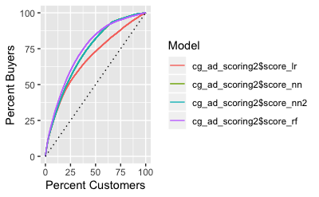

```r
gp <- gainsplot(
   cg_ad_scoring2$score_nn2,
   cg_ad_scoring2$score_nn,
   cg_ad_scoring2$score_rf,
   cg_ad_scoring2$score_lr,
   label.var=cg_ad_scoring2$converted)
```

```r
gp$auc
```

```
[1] 0.762 0.762 0.782 0.703
```

3. Calculate the profit improvement of using a neural network instead of a logistic regression (both trained on ad treatment data) to target the best 30,000 customers in the “cg_ad_scoring” sample.

```r
quartileNN <- cg_ad_scoring2 %>%
   mutate(pred_buyer_quartile_nn = ntile(-score_nn, 4)) %>%
   group_by(pred_buyer_quartile_nn) %>%
   summarise(num_cust=n(), num_buyers=sum(converted==1), resp_rate=sum(converted==1)/n(), pred_resp_rate=mean(score_lr))

# TODO: This has to be wrong... Resp Rates are way higher than Predicted Response Rate
quartileNN
```

| pred_buyer_quartile_nn | num_cust | num_buyers | resp_rate | pred_resp_rate |
| --- | --- | --- | --- | --- |
| 1 | 30000 | 8690 | 0.2897 | 0.2598 |
| 2 | 30000 | 4214 | 0.1405 | 0.1097 |
| 3 | 30000 | 2163 | 0.0721 | 0.0661 |
| 4 | 30000 | 668 | 0.0223 | 0.0884 |

```r
profitByQuartileNN <- quartileNN[1,] %>%
   mutate(revenue=num_buyers * revenue_per, cost=num_buyers * cost_per, profit=revenue-cost) %>%
   select(pred_buyer_quartile_nn, num_cust, num_buyers, resp_rate, revenue, cost, profit)

paste("Orig Profit: ", dollar(profitByQuartileNew$profit),
      "New Profit: ",  dollar(profitByQuartileNN$profit),
      "Improvement: ", dollar(profitByQuartileNN$profit -profitByQuartileNew$profit ))
```

```
[1] "Orig Profit:  $110,847 New Profit:  $117,228 Improvement:  $6,380.77"
```